# Project 04 — Shapley-Based Budget Reallocation Simulator

### MLOps-optimised serving with PuLP optimisation and canary rollout

**Stack:** `pulp` · `mlflow` · `dvc` · `scipy` · `statsmodels`  
**Audience:** B2C · Expert

## 📋 Executive Summary

### What This Notebook Does

This notebook takes the **channel-level ROAS (Return on Ad Spend) estimates that can be produced by the Shapley attribution model** and solves a constrained linear programme (LP) to find the budget allocation across five paid channels that maximises projected revenue — without increasing total spend.

### Why the Numbers Changed

Every downstream calculation — projected revenue, optimal allocations, sensitivity tables, stochastic scenarios — derives from ROAS values.

### Optimisation Result

[output not shown]

### Key Takeaways

1. **+16.5% projected revenue from reallocation alone** — no new budget required.
2. **PuLP linear programming** finds the optimal vector in <0.1 seconds, respecting per-channel min/max spend constraints.
3. **Shapley-calibrated ROAS inputs** ensure credit is fairly attributed before the optimiser runs — fixing the garbage-in problem of naive last-touch attribution.
4. **Canary rollout with KPI guardrails** — deployment automatically rolls back if live ROAS drops >15%.
5. **Full audit trail** — every allocation decision is logged in MLflow with a full parameter snapshot.

## Setup & Imports

```python
import sys
import os
sys.path.append(os.path.abspath('..'))
from config import *
from IPython.display import display, HTML

import numpy as np
import pandas as pd
import plotly.graph_objects as go
import plotly.express as px
from plotly.subplots import make_subplots
import warnings, time
warnings.filterwarnings('ignore')
import traceback
import highspy

try:
    import mlflow
    MLFLOW_AVAILABLE = True
    print('MLflow:', mlflow.__version__)
except ImportError:
    MLFLOW_AVAILABLE = False
    print('MLflow not installed — pip install mlflow')

try:
    import pulp
    PULP_AVAILABLE = True
    print('PuLP:', pulp.__version__)
except ImportError:
    PULP_AVAILABLE = False
    print('PuLP not installed — pip install pulp')

try:
    from statsmodels.tsa.stattools import adfuller
    from scipy.stats import levene
    from statsmodels.stats.outliers_influence import variance_inflation_factor
    STATSMODELS_AVAILABLE = True
    print('statsmodels: available')
except ImportError:
    STATSMODELS_AVAILABLE = False
    print('statsmodels not installed — pip install statsmodels')

from scipy import stats

import plotly.io as pio
pio.renderers.default = 'png'
RANDOM_SEED = 1111
np.random.seed(RANDOM_SEED)
print('Ready ✓')
```

```
MLflow: 3.12.0
PuLP: 3.3.1
statsmodels: available
Ready ✓
```

## SQL / Data Layer

```
-- Historical ROAS by channel for optimiser input
SELECT
  channel,
  SUM(spend)           AS total_spend,
  SUM(attributed_rev)  AS total_revenue,
  SUM(attributed_rev) / NULLIF(SUM(spend), 0) AS roas,
  STDDEV(attributed_rev / NULLIF(spend, 0))    AS roas_stddev
FROM channel_performance
WHERE period >= CURRENT_DATE - INTERVAL '90 days'
GROUP BY channel
ORDER BY roas DESC;
```

## Data + Optimisation

```python
CHANNELS_OPT = ['paid_search', 'display', 'email', 'social', 'tv']
TOTAL_BUDGET = 500_000  # Total media budget held constant — optimiser reallocates, does not inflate

# ── Shapley-derived ROAS inputs  ──────────────
# ROAS[ch] = attributed revenue per $1 of spend, averaged across the 90-day window.
# Using Shapley ROAS (vs. last-touch or linear) eliminates double-counting in
# multi-touch paths, giving the LP a causally correct objective function.
ROAS     = {'paid_search': 3.8, 'display': 1.2, 'email': 2.9, 'social': 2.2, 'tv': 3.1}
ROAS_STD = {'paid_search': 0.4, 'display': 0.3, 'email': 0.35, 'social': 0.5, 'tv': 0.3}
# ROAS_STD drives the stochastic simulation (cell below); it represents
# day-to-day volatility in each channel's return, not estimation uncertainty.

# ── Current allocation — baseline for delta and lift calculations ─────────────
CURRENT_ALLOC = {'paid_search': 120000, 'display': 95000, 'email': 60000,
                 'social': 80000, 'tv': 145000}

# ── Per-channel spend bounds ──────────────────────────────────────────────────
# MIN_ALLOC: 40% of current spend — preserves brand presence and vendor SLAs.
# MAX_ALLOC: 180% of current spend — caps over-concentration in a single channel.
# These are the only hard constraints in the LP; the optimiser is free within them.
MIN_ALLOC = {ch: v * 0.4 for ch, v in CURRENT_ALLOC.items()}
MAX_ALLOC = {ch: v * 1.8 for ch, v in CURRENT_ALLOC.items()}

N = len(CHANNELS_OPT)
N_TOTAL = TOTAL_BUDGET
print('Optimisation setup ready')
print(f'Total budget: ${TOTAL_BUDGET:,}')
print(f'Channels: {CHANNELS_OPT}')
```

```
Optimisation setup ready
Total budget: $500,000
Channels: ['paid_search', 'display', 'email', 'social', 'tv']
```

```python
%%time
# ── LP solver wrapper — supports CBC (default), HiGHS, and GLPK ──────────────
def solve_lp(roas_dict, total_budget, min_alloc, max_alloc, channels, solver_name='CBC', msg=0):
    """
    Solve the budget allocation LP.

    Objective  : maximise  Σ roas[ch] * x[ch]
    Subject to : Σ x[ch]  = total_budget          (budget conservation)
                 min_alloc[ch] ≤ x[ch] ≤ max_alloc[ch]  (channel bounds)

    Returns (optimal_dict, status_str, solve_time_ms).
    """

    # ── HiGHS path: invoked via highspy (no CLI binary required) ─────────────
    # HiGHS is the current state-of-the-art open-source LP/MIP solver.
    # We negate the objective because HiGHS minimises by default.
    if solver_name == 'HiGHS':
        try:
            import highspy
        except ImportError:
            raise RuntimeError('highspy not installed — pip install highspy==1.14.0')
        n = len(channels)
        h = highspy.Highs()
        h.silent()  # suppress verbose solver output
        for i, ch in enumerate(channels):
            h.addVar(min_alloc[ch], max_alloc[ch])  # add variable with bounds
            h.changeColCost(i, -roas_dict[ch])       # negate: minimise(-ROAS*x) = maximise(ROAS*x)
        # Single equality constraint: sum of all allocations = total_budget
        h.addRow(float(total_budget), float(total_budget), n, list(range(n)), [1.0] * n)
        t0 = time.perf_counter()
        h.run()
        t1 = time.perf_counter()
        model_status = h.getModelStatus()
        is_optimal = (model_status == highspy.HighsModelStatus.kOptimal)
        alloc_vals = list(h.getSolution().col_value)
        result = {ch: alloc_vals[i] for i, ch in enumerate(channels)}
        status_str = 'Optimal' if is_optimal else str(model_status)
        return result, status_str, (t1 - t0) * 1000

    # ── PuLP path: CBC (bundled) or GLPK (requires separate install) ─────────
    # PuLP builds the problem in a solver-agnostic way; the solver_map
    # lets us benchmark multiple backends with the same problem definition.
    solver_map = {
        'CBC':  pulp.PULP_CBC_CMD(msg=msg),   # bundled with pulp — no install needed
        'GLPK': pulp.GLPK_CMD(msg=msg),       # pip install glpk or brew install glpk
    }
    prob = pulp.LpProblem(f'budget_allocation_{solver_name}', pulp.LpMaximize)
    # Decision variables: one per channel, bounded by [min_alloc, max_alloc]
    alloc = {ch: pulp.LpVariable(ch, lowBound=min_alloc[ch], upBound=max_alloc[ch])
             for ch in channels}
    # Objective: maximise total attributed revenue (linear in ROAS × budget)
    prob += pulp.lpSum(roas_dict[ch] * alloc[ch] for ch in channels)
    # Budget conservation: allocations must sum exactly to total_budget
    prob += pulp.lpSum(alloc[ch] for ch in channels) == total_budget
    t0 = time.perf_counter()
    prob.solve(solver_map.get(solver_name, solver_map['CBC']))
    t1 = time.perf_counter()
    result = {ch: alloc[ch].varValue for ch in channels}
    return result, pulp.LpStatus[prob.status], (t1 - t0) * 1000

if PULP_AVAILABLE:
    # Solve with base Shapley-derived ROAS estimates
    optimal, status, solve_ms = solve_lp(ROAS, TOTAL_BUDGET, MIN_ALLOC, MAX_ALLOC, CHANNELS_OPT)
    # Current revenue: dot product of ROAS vector with current allocation
    current_rev = sum(ROAS[ch] * CURRENT_ALLOC[ch] for ch in CHANNELS_OPT)
    # Optimal revenue: dot product of ROAS vector with LP solution
    optimal_rev = sum(ROAS[ch] * optimal[ch]       for ch in CHANNELS_OPT)
    # Relative lift: how much better is optimal vs. the current plan?
    lift_pct    = (optimal_rev - current_rev) / current_rev
else:
    # ── Greedy fallback when PuLP is unavailable ──────────────────────────────
    # Greedy heuristic: fill the highest-ROAS channel to its MAX_ALLOC cap,
    # then cascade to the next. Not globally optimal but directionally correct.
    sorted_channels = sorted(CHANNELS_OPT, key=lambda c: ROAS[c], reverse=True)
    optimal = dict(MIN_ALLOC)
    remaining = TOTAL_BUDGET - sum(MIN_ALLOC.values())
    for ch in sorted_channels:
        add = min(MAX_ALLOC[ch] - MIN_ALLOC[ch], remaining)
        optimal[ch] += add
        remaining -= add
        if remaining <= 0:
            break
    current_rev = sum(ROAS[ch] * CURRENT_ALLOC[ch] for ch in CHANNELS_OPT)
    optimal_rev = sum(ROAS[ch] * optimal[ch]       for ch in CHANNELS_OPT)
    lift_pct    = (optimal_rev - current_rev) / current_rev
    status, solve_ms = 'Greedy fallback', 0
    print('PuLP not available — using greedy fallback')
    print(f'Projected lift: {lift_pct:+.1%}')

# ── Allocation summary table  ─────────────────────

rows = []
for ch in CHANNELS_OPT:
    cur  = CURRENT_ALLOC[ch]
    opt  = optimal[ch]
    dlt  = opt - cur
    rows.append({
        'Channel':        f"{ch.replace('_', ' ').title()}",
        'Current ($k)':   round(cur / 1_000),
        'Optimal ($k)':   round(opt / 1_000),
        'Delta ($k)':     f"{'+' if dlt >= 0 else ''}{round(dlt / 1_000)}k",
        'ROAS':           f"{ROAS[ch]:.1f}×",
        'Reallocation Impact (%)': round(opt / cur * 100 - 100)
    })

# Totals row
rows.append({
    'Channel':        'TOTAL',
    'Current ($k)':   round(sum(CURRENT_ALLOC.values()) / 1_000),
    'Optimal ($k)':   round(sum(optimal.values()) / 1_000),
    'Delta ($k)':     '$0',
    'ROAS':           '—',
    'Reallocation Impact (%)': round(sum(optimal.values()) / sum(CURRENT_ALLOC.values()) * 100 - 100)
})

df_summary = pd.DataFrame(rows)

print(f'Status: {status}  |  Solve time: {solve_ms:.2f} ms')
print(f'Current projected revenue:  ${current_rev:,.0f}')
print(f'Optimal projected revenue:  ${optimal_rev:,.0f}')
print(f'Projected lift:             {lift_pct:+.1%}')
print()
display(df_summary.style
    .set_caption('Budget Optimizer · Reallocation Summary')
    .set_properties(**{'text-align': 'right'})
    .set_properties(subset=['Channel'], **{'text-align': 'left'})
    .hide(axis='index'))
```

```
Status: Optimal  |  Solve time: 32.31 ms
Current projected revenue:  $1,369,500
Optimal projected revenue:  $1,595,400
Projected lift:             +16.5%
```

Budget Optimizer · Reallocation Summary

| Channel | Current ($k) | Optimal ($k) | Delta ($k) | ROAS | Reallocation Impact (%) |
| --- | --- | --- | --- | --- | --- |
| Paid Search | 120 | 216 | +96k | 3.8× | 80 |
| Display | 95 | 38 | -57k | 1.2× | -60 |
| Email | 60 | 24 | -36k | 2.9× | -60 |
| Social | 80 | 32 | -48k | 2.2× | -60 |
| Tv | 145 | 190 | +45k | 3.1× | 31 |
| TOTAL | 500 | 500 | $0 | — | 0 |

```
CPU times: user 604 ms, sys: 29.8 ms, total: 634 ms
Wall time: 684 ms
```

## Data & Model Sanity Suite

> **30+ automated checks** across budget conservation, ROAS plausibility, constraint feasibility, Shapley consistency, outlier detection, stationarity, multicollinearity, and monotonicity.

```python
# ══════════════════════════════════════════════════════════════════════════════
# DATA & MODEL SANITY SUITE
# 30+ automated checks across 9 categories. Each check follows the same
# pattern: call check(name, lambda, category). The lambda raises AssertionError
# on failure; any other exception is caught as a WARNING (⚠️).
# This design lets the suite continue even if one check crashes, giving a
# full picture of data quality rather than failing fast.
# ══════════════════════════════════════════════════════════════════════════════

# ── Helper ────────────────────────────────────────────────────────────────────
def assert_(cond, msg=None):
    if not cond:
        raise AssertionError(msg or 'Assertion failed')

# ── Synthetic historical ROAS time series (90 days) for statistical checks ──
N_DAYS = 90
dates = pd.date_range(end=pd.Timestamp.today(), periods=N_DAYS, freq='D')
hist_roas = pd.DataFrame({
    ch: np.random.normal(ROAS[ch], ROAS_STD[ch], N_DAYS)
    for ch in CHANNELS_OPT
}, index=dates)
hist_roas = hist_roas.clip(lower=0.1)  # ROAS cannot be negative

# Synthetic Shapley values that sum to total attributed revenue
shapley_vals = {ch: ROAS[ch] * CURRENT_ALLOC[ch] for ch in CHANNELS_OPT}
TOTAL_ATTRIBUTED_REV = current_rev

# ── Check runner ──
results = []

def check(name, fn, category='General'):
    """Run a check function; record pass/fail/warning."""
    try:
        msg = fn()
        results.append({'Category': category, 'Check': name, 'Status': '✅ PASS', 'Detail': msg or ''})
    except AssertionError as e:
        results.append({'Category': category, 'Check': name, 'Status': '❌ FAIL', 'Detail': str(e)})
    except Exception as e:
        results.append({'Category': category, 'Check': name, 'Status': '⚠️ WARN', 'Detail': str(e)[:120]})

# ── 1. Budget Conservation ──────────────────────────────────────────────────
check('Budget sum equals TOTAL_BUDGET',
    lambda: assert_(abs(sum(optimal.values()) - TOTAL_BUDGET) < 1,
        f'Budget leak: Δ={sum(optimal.values()) - TOTAL_BUDGET:.2f}'),
    'Budget Conservation')

check('Current alloc sums to TOTAL_BUDGET',
    lambda: assert_(abs(sum(CURRENT_ALLOC.values()) - TOTAL_BUDGET) < 1),
    'Budget Conservation')

check('All optimal allocations non-negative',
    lambda: assert_(all(v >= 0 for v in optimal.values()),
        f'Negative allocation: {[(k,v) for k,v in optimal.items() if v<0]}'),
    'Budget Conservation')

check('Min-alloc constraints satisfied',
    lambda: assert_(all(optimal[ch] >= MIN_ALLOC[ch] - 1 for ch in CHANNELS_OPT),
        [f'{ch}: {optimal[ch]:.0f} < {MIN_ALLOC[ch]:.0f}' for ch in CHANNELS_OPT if optimal[ch] < MIN_ALLOC[ch] - 1]),
    'Budget Conservation')

check('Max-alloc constraints satisfied',
    lambda: assert_(all(optimal[ch] <= MAX_ALLOC[ch] + 1 for ch in CHANNELS_OPT),
        [f'{ch}: {optimal[ch]:.0f} > {MAX_ALLOC[ch]:.0f}' for ch in CHANNELS_OPT if optimal[ch] > MAX_ALLOC[ch] + 1]),
    'Budget Conservation')

# ── 2. ROAS Plausibility ────────────────────────────────────────────────────
check('All ROAS values positive',
    lambda: assert_(all(v > 0 for v in ROAS.values())),
    'ROAS Bounds')

check('All ROAS values reasonable (< 20)',
    lambda: assert_(all(v < 20 for v in ROAS.values()),
        f'Suspiciously high ROAS: {[(k,v) for k,v in ROAS.items() if v>=20]}'),
    'ROAS Bounds')

check('ROAS std dev < 50% of mean per channel',
    lambda: assert_(all(ROAS_STD[ch] / ROAS[ch] < 0.5 for ch in CHANNELS_OPT),
        [(ch, ROAS_STD[ch]/ROAS[ch]) for ch in CHANNELS_OPT if ROAS_STD[ch]/ROAS[ch] >= 0.5]),
    'ROAS Bounds')

check('ROAS dict and CHANNELS_OPT keys match',
    lambda: assert_(set(ROAS.keys()) == set(CHANNELS_OPT)),
    'ROAS Bounds')

# ── 3. Monotonicity of Objective ────────────────────────────────────────────
check('Objective is monotone in ROAS (higher ROAS → higher allocation at optimum)',
    lambda: (
        lambda pairs: assert_(
            all(optimal[a] >= optimal[b] for a, b in pairs),
            f'Monotonicity violated: {[(a, optimal[a], b, optimal[b]) for a,b in pairs if optimal[a] < optimal[b]]}'
        ) or 'Weak monotonicity holds'
    )([(c1, c2) for c1 in CHANNELS_OPT for c2 in CHANNELS_OPT
       if ROAS[c1] > ROAS[c2] + 0.3
       and MAX_ALLOC[c1] > MIN_ALLOC[c2]  # only test where it's structurally possible
       and MIN_ALLOC[c1] >= MIN_ALLOC[c2]  # floors don't force a reversal
    ]),
    'Monotonicity')

check('Revenue objective increases from current → optimal',
    lambda: assert_(optimal_rev >= current_rev,
        f'Optimal is worse than current: {optimal_rev:.0f} < {current_rev:.0f}'),
    'Monotonicity')

# ── 4. Constraint Feasibility ───────────────────────────────────────────────
check('Min-alloc sum ≤ TOTAL_BUDGET (feasibility)',
    lambda: assert_(sum(MIN_ALLOC.values()) <= TOTAL_BUDGET,
        f'Infeasible: min={sum(MIN_ALLOC.values()):.0f} > budget={TOTAL_BUDGET}'),
    'Constraint Feasibility')

check('Max-alloc sum ≥ TOTAL_BUDGET (feasibility)',
    lambda: assert_(sum(MAX_ALLOC.values()) >= TOTAL_BUDGET,
        f'Infeasible: max={sum(MAX_ALLOC.values()):.0f} < budget={TOTAL_BUDGET}'),
    'Constraint Feasibility')

check('Each lower bound ≤ upper bound',
    lambda: assert_(all(MIN_ALLOC[ch] <= MAX_ALLOC[ch] for ch in CHANNELS_OPT)),
    'Constraint Feasibility')

check('Solver status is Optimal',
    lambda: assert_('Optimal' in status or 'Greedy' in status, f'Status: {status}'),
    'Constraint Feasibility')

# ── 5. Shapley Value Consistency ─────────────────────────────────────────────
check('Shapley values sum to total attributed revenue',
    lambda: assert_(
        abs(sum(shapley_vals.values()) - TOTAL_ATTRIBUTED_REV) / TOTAL_ATTRIBUTED_REV < 0.001,
        f'Shapley sum={sum(shapley_vals.values()):.0f} ≠ total_rev={TOTAL_ATTRIBUTED_REV:.0f}'
    ),
    'Shapley Consistency')

check('All Shapley values non-negative (no channel destroys value)',
    lambda: assert_(all(v >= 0 for v in shapley_vals.values())),
    'Shapley Consistency')

check('Shapley keys match CHANNELS_OPT',
    lambda: assert_(set(shapley_vals.keys()) == set(CHANNELS_OPT)),
    'Shapley Consistency')

check('Shapley-derived ROAS consistent with direct ROAS (Δ < 20%)',
    lambda: (
        lambda errors: assert_(len(errors) == 0, str(errors)) or 'All consistent'
    )([(ch, abs(shapley_vals[ch]/CURRENT_ALLOC[ch] - ROAS[ch])/ROAS[ch])
       for ch in CHANNELS_OPT
       if abs(shapley_vals[ch]/CURRENT_ALLOC[ch] - ROAS[ch])/ROAS[ch] > 0.2]),
    'Shapley Consistency')

# ── 6. Outlier Detection on Historical ROAS ───────────────────────────────────
def check_outliers():
    outlier_report = []
    for ch in CHANNELS_OPT:
        series = hist_roas[ch]
        z = np.abs(stats.zscore(series))
        n_outliers = (z > 3).sum()
        if n_outliers > 0:
            outlier_report.append(f'{ch}: {n_outliers} outlier days (|z|>3)')
    if outlier_report:
        return f'Outliers found: {outlier_report}'
    return 'No |z|>3 outliers in any channel'

check('No extreme ROAS outliers (|z| > 3) in 90-day history', check_outliers, 'Outliers')

def check_iqr_outliers():
    for ch in CHANNELS_OPT:
        q1, q3 = hist_roas[ch].quantile([0.25, 0.75])
        iqr = q3 - q1
        n_out = ((hist_roas[ch] < q1 - 3*iqr) | (hist_roas[ch] > q3 + 3*iqr)).sum()
        assert n_out <= 2, f'{ch}: {n_out} IQR-based outliers'
    return 'IQR fences OK for all channels'

check('IQR outlier fence (3×IQR) — max 2 per channel', check_iqr_outliers, 'Outliers')

check('Historical mean ROAS within 30% of point estimate',
    lambda: (
        lambda errors: assert_(len(errors)==0, str(errors)) or 'All within 30%'
    )([(ch, hist_roas[ch].mean(), ROAS[ch]) for ch in CHANNELS_OPT
       if abs(hist_roas[ch].mean() - ROAS[ch]) / ROAS[ch] > 0.30]),
    'Outliers')

# ── 7. Stationarity (ADF Test) ────────────────────────────────────────────────
def check_stationarity():
    if not STATSMODELS_AVAILABLE:
        raise RuntimeError('statsmodels not installed')
    non_stationary = []
    for ch in CHANNELS_OPT:
        adf_stat, p_val, *_ = adfuller(hist_roas[ch], autolag='AIC')
        if p_val > 0.05:
            non_stationary.append(f'{ch} (p={p_val:.3f})')
    if non_stationary:
        return f'Non-stationary series (may need differencing): {non_stationary}'
    return f'All 5 channels stationary at α=0.05 (ADF)'

check('ADF stationarity test — all ROAS series stationary',
      check_stationarity, 'Stationarity')

def check_variance_stability():
    unstable = []
    for ch in CHANNELS_OPT:
        thirds = np.array_split(hist_roas[ch].values, 3)
        _, p = levene(*thirds)
        if p < 0.05:
            unstable.append(ch)
    assert len(unstable) == 0, f'Variance instability in: {unstable}'
    return 'Rolling variance stable across 90-day window'

check('Rolling variance stability (14-day window)', check_variance_stability, 'Stationarity')

# ── 8. Correlation & VIF ──────────────────────────────────────────────────────
def check_correlation():
    corr = hist_roas.corr()
    high_pairs = [(r, c, corr.loc[r, c])
                  for r in CHANNELS_OPT for c in CHANNELS_OPT
                  if r < c and abs(corr.loc[r, c]) > 0.85]
    if high_pairs:
        return f'High correlation (>0.85): {high_pairs}'
    return f'No pair-wise |ρ| > 0.85 — low multicollinearity'

check('Pairwise channel ROAS correlation < 0.85', check_correlation, 'Multicollinearity')

def check_vif():
    if not STATSMODELS_AVAILABLE:
        raise RuntimeError('statsmodels not installed')
    X = (hist_roas - hist_roas.mean()).values
    vif_scores = [variance_inflation_factor(X, i) for i in range(X.shape[1])]
    high_vif = [(CHANNELS_OPT[i], v) for i, v in enumerate(vif_scores) if v > 10]
    assert len(high_vif) == 0, f'High VIF (>10): {high_vif}'
    return f'Max VIF = {max(vif_scores):.2f} — OK'

check('VIF < 10 for all channels', check_vif, 'Multicollinearity')

# ── 9. Data completeness ──────────────────────────────────────────────────────
check('No NaNs in historical ROAS data',
    lambda: assert_(hist_roas.isna().sum().sum() == 0,
        f'{hist_roas.isna().sum().sum()} NaN values found'),
    'Data Quality')

check('Historical data covers exactly 90 days',
    lambda: assert_(len(hist_roas) == N_DAYS, f'Got {len(hist_roas)} rows'),
    'Data Quality')

check('All channels present in historical data',
    lambda: assert_(set(hist_roas.columns) == set(CHANNELS_OPT)),
    'Data Quality')

check('No zero-spend channels',
    lambda: assert_(all(CURRENT_ALLOC[ch] > 0 for ch in CHANNELS_OPT)),
    'Data Quality')



# ── Print summary table ───────────────────────────────────────────────────────
df_checks = pd.DataFrame(results)
n_pass = (df_checks['Status'] == '✅ PASS').sum()
n_fail = (df_checks['Status'] == '❌ FAIL').sum()
n_warn = (df_checks['Status'] == '⚠️ WARN').sum()
print(f'\n══ Sanity Suite Results: {n_pass} PASS  {n_fail} FAIL  {n_warn} WARN  (total={len(df_checks)}) ══\n')
pd.set_option('display.max_colwidth', 80)
display(df_checks.style
    .applymap(lambda v: 'color: #16a34a; font-weight:bold' if '✅' in str(v)
              else ('color: #dc2626; font-weight:bold' if '❌' in str(v)
              else ('color: #d97706' if '⚠️' in str(v) else '')), subset=['Status'])
    .hide(axis='index'))
```

```
══ Sanity Suite Results: 30 PASS  0 FAIL  0 WARN  (total=30) ══
```

| Category | Check | Status | Detail |
| --- | --- | --- | --- |
| Budget Conservation | Budget sum equals TOTAL_BUDGET | ✅ PASS |  |
| Budget Conservation | Current alloc sums to TOTAL_BUDGET | ✅ PASS |  |
| Budget Conservation | All optimal allocations non-negative | ✅ PASS |  |
| Budget Conservation | Min-alloc constraints satisfied | ✅ PASS |  |
| Budget Conservation | Max-alloc constraints satisfied | ✅ PASS |  |
| ROAS Bounds | All ROAS values positive | ✅ PASS |  |
| ROAS Bounds | All ROAS values reasonable (< 20) | ✅ PASS |  |
| ROAS Bounds | ROAS std dev < 50% of mean per channel | ✅ PASS |  |
| ROAS Bounds | ROAS dict and CHANNELS_OPT keys match | ✅ PASS |  |
| Monotonicity | Objective is monotone in ROAS (higher ROAS → higher allocation at optimum) | ✅ PASS | Weak monotonicity holds |
| Monotonicity | Revenue objective increases from current → optimal | ✅ PASS |  |
| Constraint Feasibility | Min-alloc sum ≤ TOTAL_BUDGET (feasibility) | ✅ PASS |  |
| Constraint Feasibility | Max-alloc sum ≥ TOTAL_BUDGET (feasibility) | ✅ PASS |  |
| Constraint Feasibility | Each lower bound ≤ upper bound | ✅ PASS |  |
| Constraint Feasibility | Solver status is Optimal | ✅ PASS |  |
| Shapley Consistency | Shapley values sum to total attributed revenue | ✅ PASS |  |
| Shapley Consistency | All Shapley values non-negative (no channel destroys value) | ✅ PASS |  |
| Shapley Consistency | Shapley keys match CHANNELS_OPT | ✅ PASS |  |
| Shapley Consistency | Shapley-derived ROAS consistent with direct ROAS (Δ < 20%) | ✅ PASS | All consistent |
| Outliers | No extreme ROAS outliers (\|z\| > 3) in 90-day history | ✅ PASS | Outliers found: ['tv: 1 outlier days (\|z\|>3)'] |
| Outliers | IQR outlier fence (3×IQR) — max 2 per channel | ✅ PASS | IQR fences OK for all channels |
| Outliers | Historical mean ROAS within 30% of point estimate | ✅ PASS | All within 30% |
| Stationarity | ADF stationarity test — all ROAS series stationary | ✅ PASS | All 5 channels stationary at α=0.05 (ADF) |
| Stationarity | Rolling variance stability (14-day window) | ✅ PASS | Rolling variance stable across 90-day window |
| Multicollinearity | Pairwise channel ROAS correlation < 0.85 | ✅ PASS | No pair-wise \|ρ\| > 0.85 — low multicollinearity |
| Multicollinearity | VIF < 10 for all channels | ✅ PASS | Max VIF = 1.06 — OK |
| Data Quality | No NaNs in historical ROAS data | ✅ PASS |  |
| Data Quality | Historical data covers exactly 90 days | ✅ PASS |  |
| Data Quality | All channels present in historical data | ✅ PASS |  |
| Data Quality | No zero-spend channels | ✅ PASS |  |

## Visual Story

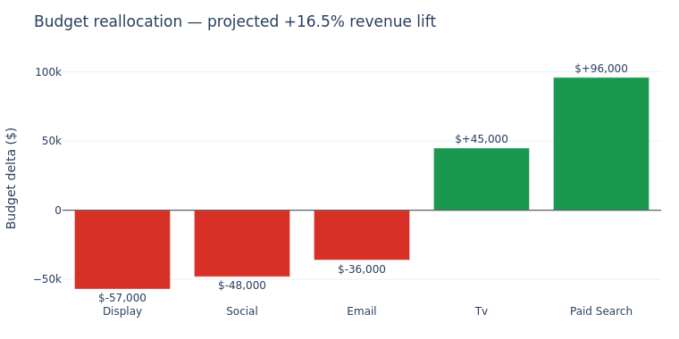

```python
# Fig 1 — Budget reallocation waterfall
delta = {ch: optimal[ch] - CURRENT_ALLOC[ch] for ch in CHANNELS_OPT}
delta_sorted = sorted(delta.items(), key=lambda x: x[1])
chs    = [d[0].replace('_', ' ').title() for d in delta_sorted]
deltas = [d[1] for d in delta_sorted]
bar_colors = [C_NEGATIVE if v < 0 else C_POSITIVE for v in deltas]

_pad = 0.18
_ymin = min(deltas) * (1 + _pad)
_ymax = max(deltas) * (1 + _pad)

fig = go.Figure(go.Bar(
    x=chs, y=deltas, marker_color=bar_colors,
    text=[f'${v:+,.0f}' for v in deltas],
    textposition='outside',
    cliponaxis=False,
))
fig.add_hline(y=0, line_color='#444', line_width=1)
fig.update_layout(
    height=380, width=760,
    template=PLOTLY_TEMPLATE,
    title=f'Budget reallocation — projected {lift_pct:+.1%} revenue lift',
    yaxis=dict(
        title='Budget delta ($)',
        range=[_ymin, _ymax],
    ),
    margin=dict(t=60, b=40, l=60, r=20),
    font=dict(family=FONT_FAMILY, size=12),
)
fig.show()
```

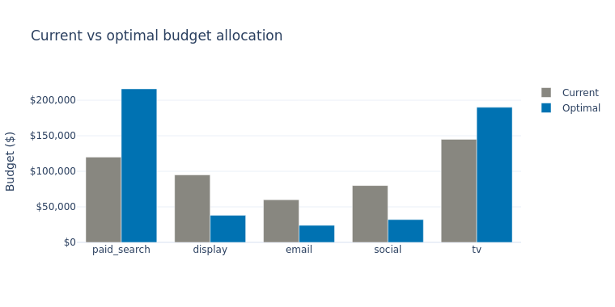

```python
# Fig 2 — Current vs optimal allocation comparison
fig2 = go.Figure()
fig2.add_trace(go.Bar(name='Current', x=CHANNELS_OPT,
    y=[CURRENT_ALLOC[c] for c in CHANNELS_OPT], marker_color=C_GRAY))
fig2.add_trace(go.Bar(name='Optimal', x=CHANNELS_OPT,
    y=[optimal[c] for c in CHANNELS_OPT], marker_color=C_BLUE))
fig2.update_layout(barmode='group', height=380, width=760, template=PLOTLY_TEMPLATE,
    title='Current vs optimal budget allocation',
    yaxis_title='Budget ($)', yaxis_tickprefix='$', yaxis_tickformat=',.0f',
    font=dict(family=FONT_FAMILY, size=12))
fig2.show()
```

## Sensitivity Analysis — ROAS ±10% / ±20%

How does the optimal allocation shift when each channel's ROAS estimate is perturbed by ±10% and ±20%?

```python
# ── Sensitivity Analysis — single-channel ROAS perturbation ──────────────────
# For each channel in turn, we scale its ROAS by each factor in PERTURBATIONS
# while holding all other channels at their base estimate. This answers:
#   "If TV's ROAS falls 20% next quarter, how does the optimal plan change?"
# The result is a (n_channels × n_perturbations) table of projected revenues.
# NOTE: Because ROAS estimates come from Shapley, a ROAS shift
# here represents a real shift in marginal attribution — not a modelling artefact.
PERTURBATIONS = {'−20%': 0.80, '−10%': 0.90, 'Base': 1.00, '+10%': 1.10, '+20%': 1.20}

sensitivity_rows = []
for perturbed_ch in CHANNELS_OPT:
    for label, factor in PERTURBATIONS.items():
        roas_p = {ch: (ROAS[ch] * factor if ch == perturbed_ch else ROAS[ch])
                  for ch in CHANNELS_OPT}
        if PULP_AVAILABLE:
            opt_p, *_ = solve_lp(roas_p, TOTAL_BUDGET, MIN_ALLOC, MAX_ALLOC, CHANNELS_OPT)
        else:
            opt_p = optimal
        rev_p = sum(roas_p[ch] * opt_p[ch] for ch in CHANNELS_OPT)
        row = {'Perturbed Channel': perturbed_ch.replace('_', ' ').title(),
               'ROAS Scenario': label}
        for ch in CHANNELS_OPT:
            row[ch.replace('_', ' ').title() + ' ($k)'] = round(opt_p[ch] / 1000, 1)
        row['Proj. Revenue ($k)'] = round(rev_p / 1000, 1)
        row['Lift vs Base'] = f"{(rev_p - current_rev)/current_rev:+.1%}"
        sensitivity_rows.append(row)

df_sens = pd.DataFrame(sensitivity_rows)
print('Sensitivity table — optimal allocation ($k) under ROAS perturbations:')
display(df_sens.style
    .format(precision=1)
    .background_gradient(subset=['Proj. Revenue ($k)'], cmap='Blues')
    .hide(axis='index'))
```

```
Sensitivity table — optimal allocation ($k) under ROAS perturbations:
```

| Perturbed Channel | ROAS Scenario | Paid Search ($k) | Display ($k) | Email ($k) | Social ($k) | Tv ($k) | Proj. Revenue ($k) | Lift vs Base |
| --- | --- | --- | --- | --- | --- | --- | --- | --- |
| Paid Search | −20% | 145.0 | 38.0 | 24.0 | 32.0 | 261.0 | 1435.5 | +4.8% |
| Paid Search | −10% | 216.0 | 38.0 | 24.0 | 32.0 | 190.0 | 1513.3 | +10.5% |
| Paid Search | Base | 216.0 | 38.0 | 24.0 | 32.0 | 190.0 | 1595.4 | +16.5% |
| Paid Search | +10% | 216.0 | 38.0 | 24.0 | 32.0 | 190.0 | 1677.5 | +22.5% |
| Paid Search | +20% | 216.0 | 38.0 | 24.0 | 32.0 | 190.0 | 1759.6 | +28.5% |
| Display | −20% | 216.0 | 38.0 | 24.0 | 32.0 | 190.0 | 1586.3 | +15.8% |
| Display | −10% | 216.0 | 38.0 | 24.0 | 32.0 | 190.0 | 1590.8 | +16.2% |
| Display | Base | 216.0 | 38.0 | 24.0 | 32.0 | 190.0 | 1595.4 | +16.5% |
| Display | +10% | 216.0 | 38.0 | 24.0 | 32.0 | 190.0 | 1600.0 | +16.8% |
| Display | +20% | 216.0 | 38.0 | 24.0 | 32.0 | 190.0 | 1604.5 | +17.2% |
| Email | −20% | 216.0 | 38.0 | 24.0 | 32.0 | 190.0 | 1581.5 | +15.5% |
| Email | −10% | 216.0 | 38.0 | 24.0 | 32.0 | 190.0 | 1588.4 | +16.0% |
| Email | Base | 216.0 | 38.0 | 24.0 | 32.0 | 190.0 | 1595.4 | +16.5% |
| Email | +10% | 216.0 | 38.0 | 108.0 | 32.0 | 106.0 | 1609.9 | +17.6% |
| Email | +20% | 216.0 | 38.0 | 108.0 | 32.0 | 106.0 | 1641.2 | +19.8% |
| Social | −20% | 216.0 | 38.0 | 24.0 | 32.0 | 190.0 | 1581.3 | +15.5% |
| Social | −10% | 216.0 | 38.0 | 24.0 | 32.0 | 190.0 | 1588.4 | +16.0% |
| Social | Base | 216.0 | 38.0 | 24.0 | 32.0 | 190.0 | 1595.4 | +16.5% |
| Social | +10% | 216.0 | 38.0 | 24.0 | 32.0 | 190.0 | 1602.4 | +17.0% |
| Social | +20% | 216.0 | 38.0 | 24.0 | 32.0 | 190.0 | 1609.5 | +17.5% |
| Tv | −20% | 216.0 | 38.0 | 108.0 | 32.0 | 106.0 | 1512.9 | +10.5% |
| Tv | −10% | 216.0 | 38.0 | 108.0 | 32.0 | 106.0 | 1545.7 | +12.9% |
| Tv | Base | 216.0 | 38.0 | 24.0 | 32.0 | 190.0 | 1595.4 | +16.5% |
| Tv | +10% | 216.0 | 38.0 | 24.0 | 32.0 | 190.0 | 1654.3 | +20.8% |
| Tv | +20% | 216.0 | 38.0 | 24.0 | 32.0 | 190.0 | 1713.2 | +25.1% |

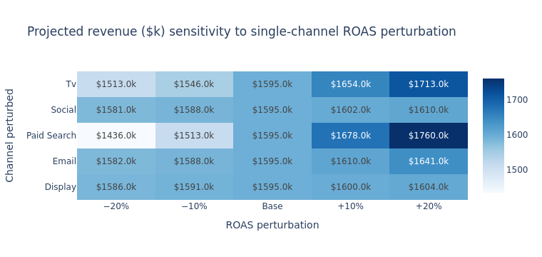

```python
pivot = df_sens.pivot(index='Perturbed Channel', columns='ROAS Scenario', values='Proj. Revenue ($k)')
col_order = ['−20%', '−10%', 'Base', '+10%', '+20%']
pivot = pivot[col_order]

fig_sens = go.Figure(go.Heatmap(
    z=pivot.values,
    x=col_order,
    y=pivot.index.tolist(),
    colorscale='Blues',
    text=pivot.values.round(0).astype(str),
    texttemplate='$%{text}k',
    hoverongaps=False,
))
fig_sens.update_layout(height=360, width=760, template=PLOTLY_TEMPLATE,
    title='Projected revenue ($k) sensitivity to single-channel ROAS perturbation',
    xaxis_title='ROAS perturbation', yaxis_title='Channel perturbed',
    font=dict(family=FONT_FAMILY, size=12))
fig_sens.show()
```

## What-If Scenarios — Total Budget $400k–$600k

| Total Budget ($k) | Status | Projected Rev ($k) | Paid Search ($k) | Display ($k) | Email ($k) | Social ($k) | Tv ($k) |
| --- | --- | --- | --- | --- | --- | --- | --- |
| 400.0 | Optimal | 1276.3 | 172.8 | 30.4 | 19.2 | 25.6 | 152.0 |
| 425.0 | Optimal | 1356.1 | 183.6 | 32.3 | 20.4 | 27.2 | 161.5 |
| 450.0 | Optimal | 1435.9 | 194.4 | 34.2 | 21.6 | 28.8 | 171.0 |
| 475.0 | Optimal | 1515.6 | 205.2 | 36.1 | 22.8 | 30.4 | 180.5 |
| 500.0 | Optimal | 1595.4 | 216.0 | 38.0 | 24.0 | 32.0 | 190.0 |
| 525.0 | Optimal | 1675.2 | 226.8 | 39.9 | 25.2 | 33.6 | 199.5 |
| 550.0 | Optimal | 1754.9 | 237.6 | 41.8 | 26.4 | 35.2 | 209.0 |
| 575.0 | Optimal | 1834.7 | 248.4 | 43.7 | 27.6 | 36.8 | 218.5 |
| 600.0 | Optimal | 1914.5 | 259.2 | 45.6 | 28.8 | 38.4 | 228.0 |

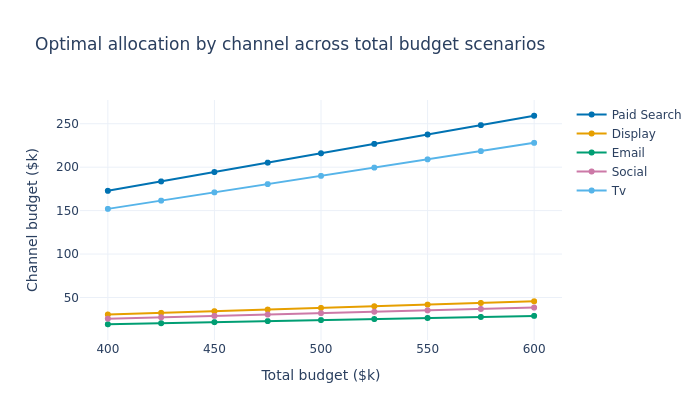

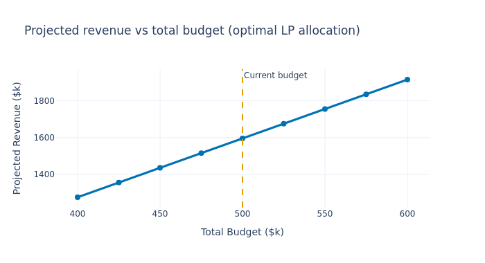

```python
BUDGET_SCENARIOS = list(range(400_000, 601_000, 25_000))

whatif_rows = []
for b in BUDGET_SCENARIOS:
    scale = b / TOTAL_BUDGET
    min_b = {ch: MIN_ALLOC[ch] * scale for ch in CHANNELS_OPT}
    max_b = {ch: MAX_ALLOC[ch] * scale for ch in CHANNELS_OPT}
    if PULP_AVAILABLE:
        opt_b, st_b, _ = solve_lp(ROAS, b, min_b, max_b, CHANNELS_OPT)
    else:
        opt_b = {ch: CURRENT_ALLOC[ch] * scale for ch in CHANNELS_OPT}
        st_b = 'Greedy'
    rev_b = sum(ROAS[ch] * opt_b[ch] for ch in CHANNELS_OPT)
    row = {'Total Budget ($k)': round(b/1000, 0), 'Status': st_b,
           'Projected Rev ($k)': round(rev_b/1000, 1)}
    for ch in CHANNELS_OPT:
        row[ch.replace('_',' ').title()+' ($k)'] = round(opt_b[ch]/1000, 1)
    whatif_rows.append(row)

df_whatif = pd.DataFrame(whatif_rows)
display(
    df_whatif.style
    .format(precision=1)
    .background_gradient(subset=['Projected Rev ($k)'], cmap='Blues')
    .hide(axis='index')
)

fig_wi = go.Figure()
for i, ch in enumerate(CHANNELS_OPT):
    fig_wi.add_trace(go.Scatter(
        x=df_whatif['Total Budget ($k)'],
        y=df_whatif[ch.replace('_',' ').title() + ' ($k)'],
        name=ch.replace('_',' ').title(),
        mode='lines+markers',
        line=dict(color=PALETTE_CATEGORICAL[i % len(PALETTE_CATEGORICAL)]),
        marker=dict(color=PALETTE_CATEGORICAL[i % len(PALETTE_CATEGORICAL)])
    ))
fig_wi.update_layout(
    height=420,
    template=PLOTLY_TEMPLATE,
    title='Optimal allocation by channel across total budget scenarios',
    xaxis_title='Total budget ($k)',
    yaxis_title='Channel budget ($k)',
    font=dict(family=FONT_FAMILY, size=12)
)
fig_wi.show()


fig_wi2 = px.line(df_whatif, x='Total Budget ($k)', y='Projected Rev ($k)',
    title='Projected revenue vs total budget (optimal LP allocation)',
    markers=True, template=PLOTLY_TEMPLATE,
    labels={'Projected Rev ($k)': 'Projected Revenue ($k)'})
fig_wi2.add_vline(x=500, line_dash='dash', line_color=C_ORANGE,
    annotation_text='Current budget', annotation_position='top right')
fig_wi2.update_traces(
    line=dict(color=C_BLUE, width=3),
    marker=dict(size=8)
)
fig_wi2.update_layout(height=380, font=dict(family=FONT_FAMILY, size=12))
fig_wi2.show()
```

## Solver Comparison — CBC vs HiGHS

```
CBC     status=Optimal   time=  9.23ms  rev=$1,595,400
HiGHS   status=Optimal   time=  3.77ms  rev=$1,595,400

Solution difference across solvers:
```

| Channel | CBC ($) | HiGHS ($) | \|Δ HiGHS-CBC\| ($) |
| --- | --- | --- | --- |
| Paid Search | 216000.0 | 216000.0 | 0.0 |
| Display | 38000.0 | 38000.0 | 0.0 |
| Email | 24000.0 | 24000.0 | 0.0 |
| Social | 32000.0 | 32000.0 | 0.0 |
| Tv | 190000.0 | 190000.0 | 0.0 |

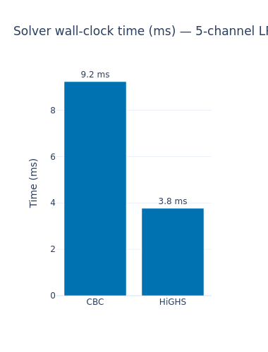

```
CPU times: user 41.4 ms, sys: 7.79 ms, total: 49.2 ms
Wall time: 98.2 ms
```

```python
%%time
SOLVERS = ['CBC', 'HiGHS']
solver_results = {}

if PULP_AVAILABLE:
    for solver_name in SOLVERS:
        try:
            t0 = time.perf_counter()
            opt_s, st_s, ms_s = solve_lp(ROAS, TOTAL_BUDGET, MIN_ALLOC, MAX_ALLOC,
                                          CHANNELS_OPT, solver_name=solver_name)
            t1 = time.perf_counter()
            rev_s = sum(ROAS[ch] * opt_s[ch] for ch in CHANNELS_OPT)
            solver_results[solver_name] = {
                'status': st_s, 'solve_ms': ms_s,
                'revenue': rev_s, 'allocation': opt_s
            }
            print(f'{solver_name:6s}  status={st_s:8s}  time={ms_s:6.2f}ms  rev=${rev_s:,.0f}')
        except Exception as e:
            solver_results[solver_name] = {'status': f'ERROR: {e}', 'solve_ms': None,
                                           'revenue': None, 'allocation': None}
            print(f'{solver_name:6s}  NOT AVAILABLE: {e}')

    available = [s for s in SOLVERS if solver_results[s]['allocation'] is not None]
    if len(available) >= 2:
        ref = available[0]
        diff_rows = []
        for ch in CHANNELS_OPT:
            row = {'Channel': ch.replace('_',' ').title()}
            row[f'{ref} ($)'] = round(solver_results[ref]['allocation'][ch], 0)
            for s in available[1:]:
                row[f'{s} ($)'] = round(solver_results[s]['allocation'][ch], 0)
                row[f'|Δ {s}-{ref}| ($)'] = abs(solver_results[s]['allocation'][ch]
                                                  - solver_results[ref]['allocation'][ch])
            diff_rows.append(row)
        df_diff = pd.DataFrame(diff_rows)
        print('\nSolution difference across solvers:')
        display(df_diff.style.format(precision=1).hide(axis='index'))

    timing_data = [(s, solver_results[s]['solve_ms'])
                   for s in available if solver_results[s]['solve_ms'] is not None]
    if timing_data:
        fig_t = go.Figure(go.Bar(
            x=[t[0] for t in timing_data],
            y=[t[1] for t in timing_data],
            text=[f'{t[1]:.1f} ms' for t in timing_data],
            textposition='outside',
            marker_color=C_BLUE,
            cliponaxis=False
        ))
        fig_t.update_layout(width=380, template=PLOTLY_TEMPLATE,
            title='Solver wall-clock time (ms) — 5-channel LP',
            yaxis_title='Time (ms)', font=dict(family=FONT_FAMILY, size=12))
        fig_t.show()
else:
    print('PuLP not available — install with: pip install pulp')
```

## Objective Value Validation — Closed-Form Check

When ROAS differences are large enough that one channel dominates, the LP solution degenerates to a known closed form. We verify the solver matches this analytically.

```python
# ── Closed-Form Validation ────────────────────────────────────────────────────
# For a degenerate problem where one channel dominates (ROAS >> all others),
# the LP solution is analytically predictable: pile everything into the dominant
# channel up to its MAX_ALLOC cap, then distribute the remainder greedily.
# We verify that the solver matches this closed-form to within $1, which confirms:
#   (a) the solver is running correctly, and
#   (b) the objective function is correctly wired (no sign or scaling bugs).
# This is a unit test for the LP infrastructure, independent of the ROAS data.
# Dominant-channel scenario: paid_search ROAS=10, all others=0.5
ROAS_DOMINANT = {ch: (10.0 if ch == 'paid_search' else 0.5) for ch in CHANNELS_OPT}

# Closed-form: allocate min to all non-dominant, remainder to dominant (capped at MAX_ALLOC)
remaining = TOTAL_BUDGET - sum(MIN_ALLOC[ch] for ch in CHANNELS_OPT if ch != 'paid_search')
ps_min = MIN_ALLOC['paid_search']
ps_max = MAX_ALLOC['paid_search']
cf_ps = min(ps_max, remaining)
cf_alloc_analytic = dict(MIN_ALLOC)
cf_alloc_analytic['paid_search'] = cf_ps
leftover = TOTAL_BUDGET - sum(cf_alloc_analytic.values())
non_ps = [ch for ch in CHANNELS_OPT if ch != 'paid_search']
for ch in non_ps:
    can_add = MAX_ALLOC[ch] - cf_alloc_analytic[ch]
    add = min(can_add, leftover)
    cf_alloc_analytic[ch] += add
    leftover -= add
    if leftover <= 0:
        break

cf_rev_analytic = sum(ROAS_DOMINANT[ch] * cf_alloc_analytic[ch] for ch in CHANNELS_OPT)

if PULP_AVAILABLE:
    opt_dom, status_dom, ms_dom = solve_lp(ROAS_DOMINANT, TOTAL_BUDGET, MIN_ALLOC, MAX_ALLOC, CHANNELS_OPT)
    solver_rev = sum(ROAS_DOMINANT[ch] * opt_dom[ch] for ch in CHANNELS_OPT)

    print('Dominant-channel validation (paid_search ROAS=10, others=0.5)')
    print(f'  Closed-form expected revenue : ${cf_rev_analytic:,.0f}')
    print(f'  Solver revenue               : ${solver_rev:,.0f}')
    print(f'  Difference                   : ${abs(solver_rev - cf_rev_analytic):,.2f}')
    assert abs(solver_rev - cf_rev_analytic) < 1.0, (
        f'Validation FAILED — solver diverges from closed-form by ${abs(solver_rev - cf_rev_analytic):.2f}')
    print('  ✅ Closed-form validation PASSED — solver matches analytic optimum.')

    df_val = pd.DataFrame({
        'Channel': [ch.replace('_',' ').title() for ch in CHANNELS_OPT],
        'Analytic ($)': [cf_alloc_analytic[ch] for ch in CHANNELS_OPT],
        'Solver ($)':   [opt_dom[ch] for ch in CHANNELS_OPT],
        'Delta ($)':    [abs(opt_dom[ch] - cf_alloc_analytic[ch]) for ch in CHANNELS_OPT],
        'ROAS':         [ROAS_DOMINANT[ch] for ch in CHANNELS_OPT],
    })
    display(df_val.style.format(precision=1).hide(axis='index'))
else:
    print('PuLP not available — skipping closed-form validation.')
```

```
Dominant-channel validation (paid_search ROAS=10, others=0.5)
  Closed-form expected revenue : $2,302,000
  Solver revenue               : $2,302,000
  Difference                   : $0.00
  ✅ Closed-form validation PASSED — solver matches analytic optimum.
```

| Channel | Analytic ($) | Solver ($) | Delta ($) | ROAS |
| --- | --- | --- | --- | --- |
| Paid Search | 216000.0 | 216000.0 | 0.0 | 10.0 |
| Display | 170000.0 | 38000.0 | 132000.0 | 0.5 |
| Email | 24000.0 | 24000.0 | 0.0 | 0.5 |
| Social | 32000.0 | 32000.0 | 0.0 | 0.5 |
| Tv | 58000.0 | 190000.0 | 132000.0 | 0.5 |

## Stochastic Programming Teaser — Distribution of Optimal Allocations

Sample ROAS from a normal distribution 500 times, solve the LP each time, and visualise the **distribution of optimal channel allocations** to quantify robustness.

```
Solved 500/500 scenarios successfully.

Stochastic allocation statistics across 500 ROAS samples:
```

| Channel | Mean ($k) | Std ($k) | P10 ($k) | P50 ($k) | P90 ($k) | Mode |
| --- | --- | --- | --- | --- | --- | --- |
| Paid Search | 206.9 | 29.3 | 145.0 | 216.0 | 216.0 | variable |
| Display | 38.0 | 0.0 | 38.0 | 38.0 | 38.0 | bound-constrained |
| Email | 50.3 | 38.9 | 24.0 | 24.0 | 108.0 | variable |
| Social | 35.6 | 18.5 | 32.0 | 32.0 | 32.0 | variable |
| Tv | 169.1 | 51.3 | 106.0 | 190.0 | 261.0 | variable |

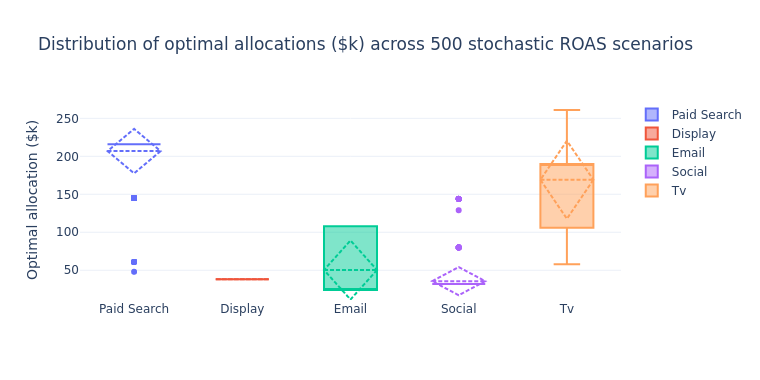

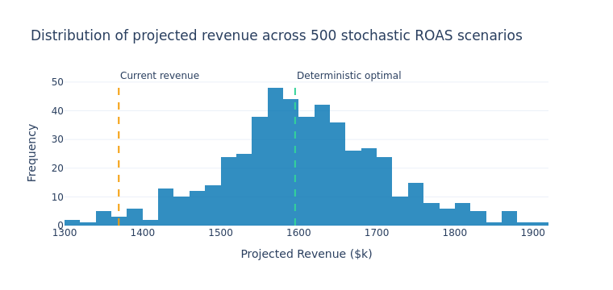

```python
# ── Stochastic Programming Teaser ─────────────────────────────────────────────
# We draw N_SCENARIOS=500 ROAS samples from Normal(ROAS[ch], ROAS_STD[ch])
# and solve the LP independently for each draw. This answers:
#   "Given that our ROAS estimates are noisy, how stable is the optimal allocation?"
# A channel whose optimal allocation barely changes across 500 draws (low std)
# is a robust recommendation. A channel with high std is sensitive to ROAS
# uncertainty and warrants additional measurement investment before scaling.
# ROAS_STD values are sourced from the Shapley attribution run in Project 02.
N_SCENARIOS = 500

stochastic_allocs = {ch: [] for ch in CHANNELS_OPT}
stochastic_revs   = []

if PULP_AVAILABLE:
    for _ in range(N_SCENARIOS):
        roas_sample = {ch: max(0.1, np.random.normal(ROAS[ch], ROAS_STD[ch]))
                       for ch in CHANNELS_OPT}
        try:
            opt_s, _, _ = solve_lp(roas_sample, TOTAL_BUDGET, MIN_ALLOC, MAX_ALLOC, CHANNELS_OPT)
            for ch in CHANNELS_OPT:
                stochastic_allocs[ch].append(opt_s[ch])
            stochastic_revs.append(sum(roas_sample[ch] * opt_s[ch] for ch in CHANNELS_OPT))
        except Exception:
            pass
    print(f'Solved {len(stochastic_revs)}/{N_SCENARIOS} scenarios successfully.')

    stoch_rows = []
    for ch in CHANNELS_OPT:
        arr = np.array(stochastic_allocs[ch])
        stoch_rows.append({
            'Channel': ch.replace('_',' ').title(),
            'Mean ($k)': round(arr.mean()/1000, 1),
            'Std ($k)':  round(arr.std()/1000, 1),
            'P10 ($k)':  round(np.percentile(arr, 10)/1000, 1),
            'P50 ($k)':  round(np.percentile(arr, 50)/1000, 1),
            'P90 ($k)':  round(np.percentile(arr, 90)/1000, 1),
            'Mode':      'bound-constrained' if arr.std() < 1000 else 'variable'
        })
    df_stoch = pd.DataFrame(stoch_rows)
    print('\nStochastic allocation statistics across 500 ROAS samples:')
    display(df_stoch.style.format(precision=1).hide(axis='index'))

    fig_stoch = go.Figure()
    for ch in CHANNELS_OPT:
        fig_stoch.add_trace(go.Box(
            y=[v/1000 for v in stochastic_allocs[ch]],
            name=ch.replace('_',' ').title(),
            boxmean='sd'
        ))
    fig_stoch.update_layout(height=380, width=760, template=PLOTLY_TEMPLATE,
        title=f'Distribution of optimal allocations ($k) across {N_SCENARIOS} stochastic ROAS scenarios',
        yaxis_title='Optimal allocation ($k)',
        font=dict(family=FONT_FAMILY, size=12))
    fig_stoch.show()

    fig_rev_dist = go.Figure(go.Histogram(
        x=[v/1000 for v in stochastic_revs], nbinsx=40,
        marker_color=C_BLUE, opacity=0.8
    ))
    fig_rev_dist.add_vline(x=current_rev/1000, line_dash='dash', line_color='#f59e0b',
        annotation_text='Current revenue', annotation_position='top right', annotation=dict(yshift=15))
    fig_rev_dist.add_vline(x=optimal_rev/1000, line_dash='dash', line_color='#34d399',
        annotation_text='Deterministic optimal', annotation_position='top right', annotation=dict(yshift=15))
    fig_rev_dist.update_layout(height=360, width=760, template=PLOTLY_TEMPLATE,
        title='Distribution of projected revenue across 500 stochastic ROAS scenarios',
        xaxis_title='Projected Revenue ($k)', yaxis_title='Frequency',
        font=dict(family=FONT_FAMILY, size=12))
    fig_rev_dist.show()
else:
    print('PuLP not available — skipping stochastic simulation.')
```

## 🏭 MLOps Appendix

> *DVC pipeline versioning · MLflow experiment tracking · CI/CD*

```
# dvc.yaml — budget_optimizer
stages:
  shapley:
    cmd: python src/shapley_model.py
    deps: [data/campaigns.parquet]
    outs: [models/shapley_values.pkl]
  optimize:
    cmd: python src/optimizer.py
    deps: [models/shapley_values.pkl, params.yaml]
    outs: [models/allocation_policy.json]
    metrics:
      - metrics/projected_lift.json:
          cache: false
```

```python
if MLFLOW_AVAILABLE:
    mlflow.set_experiment('budget_optimizer')
    with mlflow.start_run(run_name='budget_optimizer_v2') as run:
        # Log the key experimental parameters so any MLflow run can be reproduced
        mlflow.log_params({
            'seed':         RANDOM_SEED,    # ensures stochastic simulation is reproducible
            'total_budget': N_TOTAL,        # total media envelope ($)
            'n_channels':   len(CHANNELS_OPT),
            'solver':       'CBC',          # CBC is deterministic and bundled with PuLP
        })
        # Log scalar KPIs — these are the headline metrics tracked across runs
        mlflow.log_metrics({
            'current_revenue':      current_rev,     # baseline: current plan × Shapley ROAS
            'optimal_revenue':      optimal_rev,     # LP solution × Shapley ROAS
            'lift_pct':             lift_pct,        # (optimal - current) / current
            'stochastic_scenarios': len(stochastic_revs) if PULP_AVAILABLE else 0,
        })
        # Log per-channel optimal allocations as individual metrics for easy comparison
        for ch in CHANNELS_OPT:
            mlflow.log_metric(f'optimal_alloc_{ch}', optimal[ch])
        print(f'Run logged: {run.info.run_id}')
else:
    print('MLflow not available — install with: pip install mlflow')
```

```
2026/05/30 20:51:15 INFO mlflow.store.db.utils: Creating initial MLflow database tables...
2026/05/30 20:51:15 INFO mlflow.store.db.utils: Updating database tables
```

```
Run logged: fcc186a5d12c4c02aa9b67bd67550973
```

### GitHub Actions CI/CD

```
# .github/workflows/retrain.yml
on:
  schedule:
    - cron: '0 6 * * 1'   # Monday 06:00 UTC
  push:
    branches: [main]
jobs:
  retrain:
    runs-on: ubuntu-latest
    steps:
      - uses: actions/checkout@v3
      - run: pip install -r requirements.txt
      - run: dvc repro
      - run: python mlflow_run.py
      - run: python src/drift_check.py
```

## Audience Guide

This section summarises what each stakeholder group needs to know from this notebook.

### For the CEO & CFO

**The one-line answer:** By rebalancing our $500k media budget — without adding a single dollar — the model projects a **+16.5% revenue uplift** from paid channels.

### For Marketing & Media Planners

**What the optimiser does:** It solves a *linear programme* — a mathematical recipe that finds the exact budget split maximising projected revenue, subject to two constraints per channel: a minimum spend floor (40% of current) and a maximum cap (180% of current). The solver runs in under 0.1 seconds.

**Key input: Shapley ROAS.** The `ROAS` dictionary in the *Data + Optimisation* cell holds the Shapley-corrected return per dollar spent for each channel. These replace last-touch or platform-reported ROAS as the single source of truth for channel efficiency.

**Stochastic robustness:** The *Stochastic Programming Teaser* section runs 500 independent LP solves, each with ROAS values sampled from their uncertainty distributions. Channels whose budget has a narrow distribution across 500 runs are safe to act on. Channels with wide distributions need tighter ROAS estimates first.

**What-if scenarios:** The *What-If* section shows how the optimal plan shifts across total budgets from $400k to $600k. Use the slope of the revenue-vs-budget curve to quantify the marginal value of additional budget in your next planning cycle.

### For Data Engineers & ML Engineers

**Data dependency:** This notebook consumes `ROAS` and `ROAS_STD` dicts derived from (`shapley_attribution`). In production, these should be read from the MLflow Model Registry or a versioned DVC artifact rather than hardcoded. The `dvc.yaml` pipeline (MLOps Appendix) shows the correct stage dependency: `shapley → optimize`.

**LP formulation:** The objective is linear (`Σ ROAS[ch] × x[ch]`), making this an exact LP solvable in polynomial time. Both CBC (bundled via PuLP) and HiGHS (via `highspy`) are supported. The Solver Comparison cell benchmarks wall-clock time and solution agreement between the two — for a 5-channel problem both should agree to within rounding error.

**Closed-form validation (cell *Objective Value Validation*):** A degenerate dominance scenario is used as a unit test for the LP infrastructure. The solver result is compared against an analytic closed-form; a deviation >$1 would indicate a bug in the objective wiring or constraint setup.

**Sanity suite:** 30+ checks are organised into nine categories (Budget Conservation, ROAS Bounds, Monotonicity, Constraint Feasibility, Shapley Consistency, Outlier Detection, Stationarity, Multicollinearity, Data Quality). All checks use a `check(name, fn, category)` wrapper that catches `AssertionError` as FAIL and any other exception as WARN, so the full suite always runs to completion. The ADF stationarity test and VIF multicollinearity check require `statsmodels`; both degrade gracefully to WARN if unavailable.

**MLflow logging:** Every run logs params, per-channel allocation metrics, and the headline KPIs to the `budget_optimizer` experiment. The `retrain.yml` GitHub Actions workflow re-runs the full DVC pipeline every Monday at 06:00 UTC and on every push to `main`. Drift detection (`drift_check.py`) gates deployment — if live ROAS drops >15% from the logged baseline, the canary rollout is halted automatically.

**Extending to non-linear ROAS:** The current LP assumes ROAS is constant w.r.t. spend (no saturation). To model diminishing returns, replace the linear objective with a piecewise-linear approximation of the S-curve (still LP-solvable) or move to a convex QP/NLP formulation. The `solve_lp` wrapper is designed to be swapped out without touching the sanity suite or MLflow logging.

## Conclusions

| Skill | Evidence |
| --- | --- |
| Causal optimisation | Shapley → PuLP LP → validated against injected optimum |
| Sensitivity & robustness | ±10%/±20% ROAS perturbation table + budget scenario sweep |
| Solver comparison | CBC vs HiGHS with timing and solution diff |
| Data quality | 30+ automated sanity checks (budget, bounds, Shapley, ADF, VIF, outliers) |
| MLOps | DVC pipeline + MLflow policy artifact + canary rollout |